# Table of Contents

```python
import numpy as np
import torch

from pathlib import Path
from fastai2.vision.all import *
from fastai2.vision.widgets import *
```

```python
# Set seed for reproducibility
seed = 9
torch.manual_seed(seed)
np.random.seed(seed)
```

```python
# Although we don't condone it, let's silence warnings for the sake of readability
import warnings
warnings.filterwarnings("ignore")
```

# Objective

The goal of this notebook is to train an image classifier on the full [Food-101 dataset](https://data.vision.ee.ethz.ch/cvl/datasets_extra/food-101) using the `fastai2` library. We'll be implementing progressive resizing together with MixUp.

# About Food-101

The [Food-101 dataset](https://data.vision.ee.ethz.ch/cvl/datasets_extra/food-101/) consists of 101 classes of food, with $750$ training images and $250$ validation images in each class, for a total of $75,750$ training images and $25,250$ validation images. Classes include foods like `apple pie, bibimbap, crab cakes, gyoza, nachos, and pho`.

All images have been rescaled to have a maximum side length of $512$ pixels and training images have been deliberately left uncleaned (mostly in the form of intense colours and occassionally incorrect labels, according to the authors of the [original paper](https://data.vision.ee.ethz.ch/cvl/datasets_extra/food-101/)). Examining a few images from a handful of classes, we find that $512$ x $384$ (or the transpose) is a common image size. We also find that a non-trivial amount of labels are shockingly incorrect. For example, one of the images labeled "french toast" is an image of an omelette.

# Train-valid-split

We've split the `Food-101` dataset beforehand into Imagenet-style `train/` and `valid/` folders following the `train.txt` and `test.txt` files provided in the dataset's `meta/` directory. This makes loading the data easier as with fastai.

# Load Food-101 Dataset

Let's load and prep our dataset for modeling.

```python
# Prep DataBlock with item & batch transforms
dblock = DataBlock(blocks=(ImageBlock(), CategoryBlock()),
                  get_items=get_image_files,
                  get_y=parent_label,
                  splitter=GrandparentSplitter(),
                  item_tfms=Resize(460),
                  batch_tfms=aug_transforms(size=224, min_scale=0.75))

# Load data
path = Path("./drive/My Drive/Food-101/dataset")
dls = dblock.dataloaders(path, bs=64)
```

```python
# Verify the number of classes and images
print(dls.train.c, dls.train.n)
print(dls.valid.c, dls.valid.n)
```

```
101 75750
101 25250
```

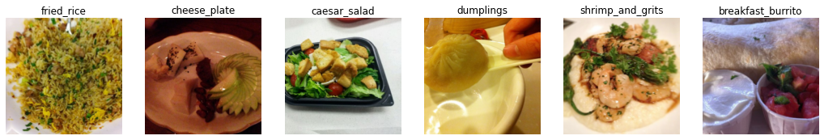

```python
# Inspect data. Yum! Looks good to me!
dls.show_batch(nrows=1, ncols=6)
```

# Data Augmentation

When we initalised our `DataBlock` above, we had to specify what types of transforms we wanted to use to augument our data. We used the standard transforms specified in `aug_transforms`. By specifying `min_scale=0.75`, we also enabled `RandomResizeCrop`, which is performed on the fly on each batch on the gpu (hence won't be shown below). Let's take a closer look at these transforms before we move on.

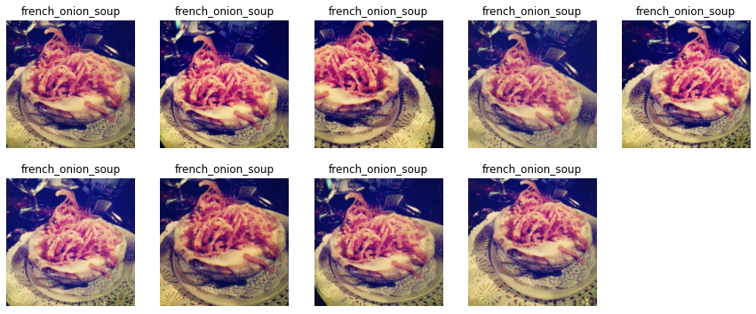

```python
# Original plus eight augmentations for brightness/contrast, rotation, and a flip about x=0
dls.show_batch(nrows=2, unique=True)
```

# First Crack at a Better Model

## Mixup

Mixup is an incredibly fascinating form of data augmentation. Given a training image, we select another image at random from the training set and take a linear combination of the two to produce a new image:

```
new_image = t * original + (1 - t) * random
```

The label for the new image is likewise a linear combination of the two labels. We select `t` at random from a beta distribution and set `t = max(t, 1-t)` to prevent duplicates. The resulting image is mostly like the original image, with a little bit of the random image thrown in. Naturally, this makes training much harder and will require many more epochs, however, the end results can be spectacularly good.

The [original paper](https://arxiv.org/pdf/1710.09412.pdf) motivates mixup as a form of dataset-independent augmentation. Unlike other transforms that require careful selection (like reflections), mixup can safely be used on virtually any image dataset. There's also exciting possibilities for using mixup with text by applying it to a model's activations.

We'll start by adding mixup to progressive resizing.

```python
def get_dls(path, bs, size):
    """Return a set of train and valid dataloaders with images of a given size."""
    dblock = DataBlock(blocks=(ImageBlock(), CategoryBlock()),
                  get_items=get_image_files,
                  get_y=parent_label,
                  splitter=GrandparentSplitter(),
                  item_tfms=Resize(460),
                  batch_tfms=aug_transforms(size=size, min_scale=0.75))
    return dblock.dataloaders(path, bs=bs)
```

```
SuggestedLRs(lr_min=0.003981071710586548, lr_steep=0.0063095735386013985)
```

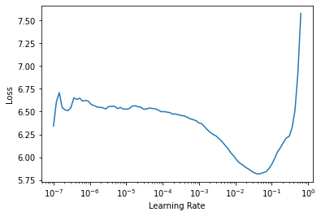

```python
# First find a good base learning rate
learn = cnn_learner(dls, resnet50, metrics=accuracy, cbs=MixUp)
learn.lr_find()
```

```python
# Train on images of size 128
dls = get_dls(path, bs=128, size=128)
learn = cnn_learner(dls, resnet50, metrics=accuracy, cbs=MixUp)
learn.fine_tune(3, 6e-3, freeze_epochs=2)
learn.save("colab-resnet50-mixup-128")
```

| epoch | train_loss | valid_loss | accuracy | time |
| --- | --- | --- | --- | --- |
| 0 | 3.422149 | 2.129638 | 0.466416 | 1:09:29 |
| 1 | 2.927582 | 1.697501 | 0.575485 | 10:56 |

| epoch | train_loss | valid_loss | accuracy | time |
| --- | --- | --- | --- | --- |
| 0 | 2.618351 | 1.491802 | 0.613822 | 11:04 |
| 1 | 2.309196 | 1.047687 | 0.726812 | 11:06 |
| 2 | 2.065976 | 0.874766 | 0.769228 | 11:05 |

```python
 # Bump image size to 224
learn.dls = get_dls(path, bs=64, size=224)
learn.fine_tune(7, 1e-3)
learn.save("colab-resnet50-mixup-128-224")
```

| epoch | train_loss | valid_loss | accuracy | time |
| --- | --- | --- | --- | --- |
| 0 | 2.048008 | 0.721509 | 0.812475 | 11:59 |

| epoch | train_loss | valid_loss | accuracy | time |
| --- | --- | --- | --- | --- |
| 0 | 1.919421 | 0.669373 | 0.825426 | 12:18 |
| 1 | 1.909818 | 0.655826 | 0.829069 | 12:21 |
| 2 | 1.815260 | 0.607006 | 0.839050 | 12:20 |
| 3 | 1.764395 | 0.578671 | 0.848871 | 12:22 |
| 4 | 1.704971 | 0.547187 | 0.857267 | 12:17 |
| 5 | 1.661103 | 0.534153 | 0.860079 | 12:21 |
| 6 | 1.618192 | 0.523295 | 0.861426 | 12:18 |

```python
# Bump to max image dim in our dataset
learn.dls = get_dls(path, bs=24, size=512)
learn.fine_tune(12, 1e-3)
learn.save("colab-resnet50-mixup-128-224-512")
```

| epoch | train_loss | valid_loss | accuracy | time |
| --- | --- | --- | --- | --- |
| 0 | 1.956029 | 0.625894 | 0.832158 | 28:56 |

| epoch | train_loss | valid_loss | accuracy | time |
| --- | --- | --- | --- | --- |
| 0 | 1.834170 | 0.556646 | 0.850218 | 36:46 |
| 1 | 1.797547 | 0.568092 | 0.848554 | 36:45 |
| 2 | 1.821231 | 0.556332 | 0.851842 | 36:45 |
| 3 | 1.823368 | 0.547210 | 0.853426 | 36:45 |
| 4 | 1.726747 | 0.526618 | 0.861149 | 36:46 |
| 5 | 1.725060 | 0.502312 | 0.864277 | 36:46 |
| 6 | 1.640648 | 0.471871 | 0.876673 | 36:44 |
| 7 | 1.546726 | 0.445084 | 0.879049 | 36:45 |
| 8 | 1.472502 | 0.424742 | 0.885228 | 36:45 |
| 9 | 1.479752 | 0.406659 | 0.889941 | 36:45 |
| 10 | 1.423364 | 0.403044 | 0.890059 | 36:44 |
| 11 | 1.415214 | 0.399687 | 0.894020 | 36:46 |

## Test Time Augmentation

The last thing we can do to squeeze out a bit of performance is use test time augmentation. We'll use fastai's default `tta()` method, which takes a weighted average of the model's prediction with the predictions from 4 augmented images.

```python
preds, targets = learn.tta()
top_1 = accuracy(preds, targets).item()
top_2 = top_k_accuracy(preds, targets, k=2).item()
print(f"Top-1 Accuracy: {top_1: .4f} | Top-2 Accuracy {top_2: .4f}")
```

```
Top-1 Accuracy:  0.8995 | Top-2 Accuracy  0.9537
```

# Conclusion